# Project1

Joshua Ludwig

2023-10-27

### Introduction to the Six General Models

We have considered six different models, each described by a mathematical equation that characterizes the behavior of LED light bulbs over time. These models incorporate various parameters that influence the bulbs’ intensity and lifespan.

```r
rm(list=ls())
library(data4led)
bulb <- led_bulb(1,seed = 1228)

t <- bulb$hours
y <- bulb$percent_intensity

f2 <- function(x,a0=0,a1=0,a2=1){ a0 + a1*x + a2*x^2 }
f3 <- function(x,a0=100,a1=0,a2=1){ (100-a1) + a1*exp(-a2*x) }
f4 <- function(x,a0=0,a1=0,a2=1){a0+a1*x+a2*log(0.005*x+1)}
f5 <- function(x,a0=100,a1=0,a2=1){ (a0 + a1*x)*exp(-a2*x) }

x <- seq(-10,160001,2)
y0 <- f2(x,a0=100,a1=0,a2=0)
y1 <- f2(x,a0=100,a1=6e-4,a2=0)
y2 <- f2(x,a0=100,a1=.95e-3,a2=-1.3e-7)
y3 <- f3(x,a0=101.3,a1=-1.3,a2=0.00114)
y4 <- f4(x,a0=100,a1=-2.4e-4,a2=0.9)
y5 <- f5(x,a0=100,a1=6e-3,a2=4.95e-5)

result_y2 <- uniroot(function(x) f2(x, a0 = 100, a1 = 0.95e-3, a2 = -1.3e-7) - 80, interval = c(0, 80000))
result_y4 <- uniroot(function(x) f4(x, a0 = 100, a1 = -2.4e-4, a2 = 0.9) - 80, interval = c(0, 160000))
result_y5 <- uniroot(function(x) f5(x, a0 = 100, a1 = 6e-3, a2 = 4.95e-5) - 80, interval = c(0, 80000))
```

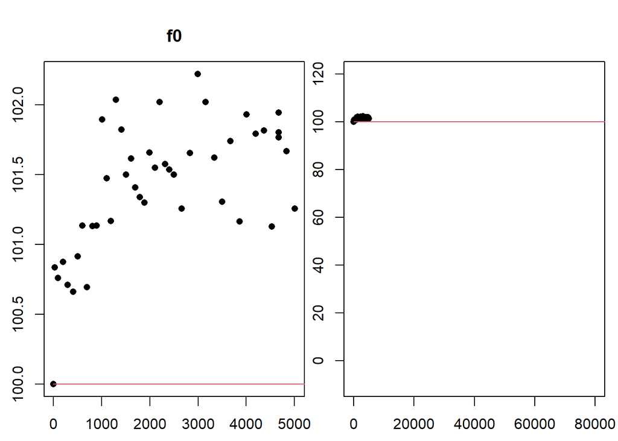

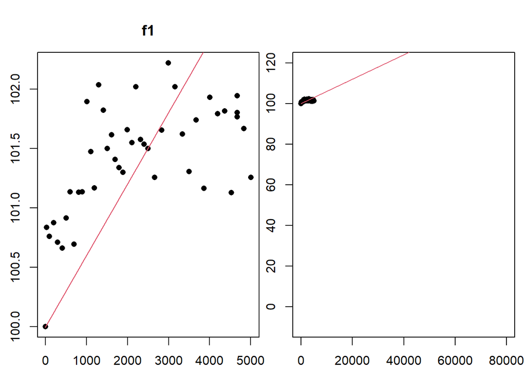

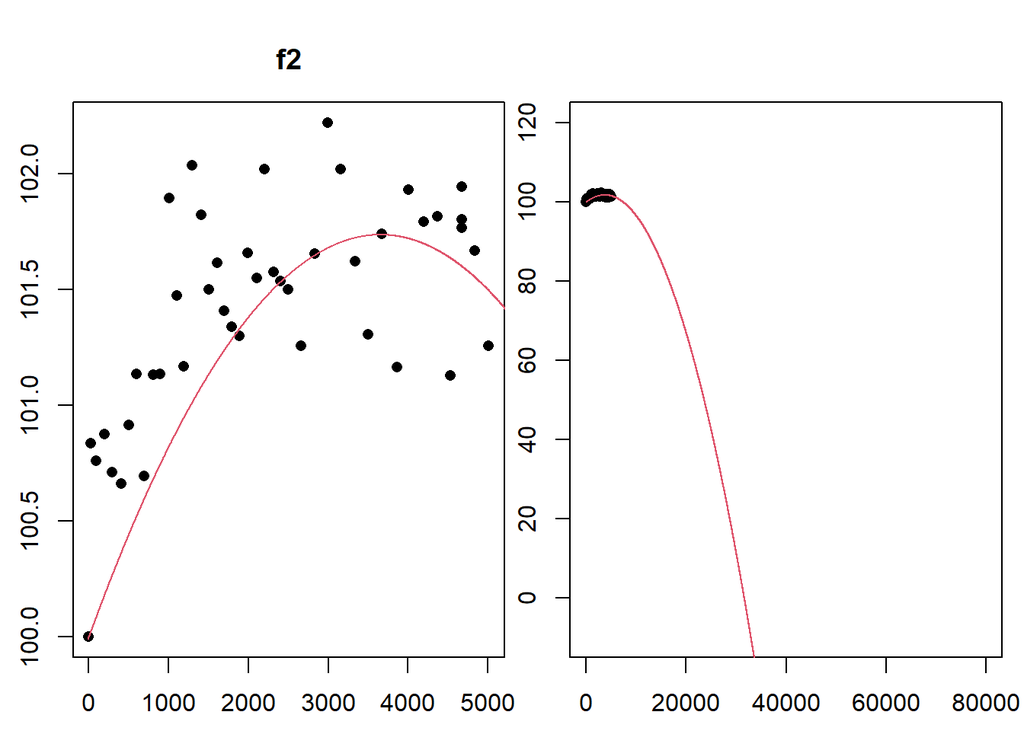

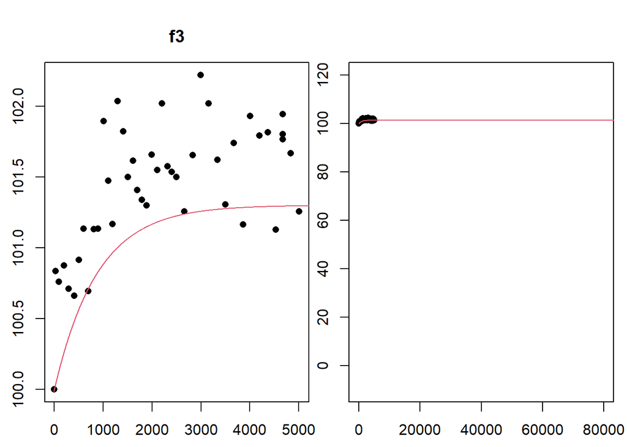

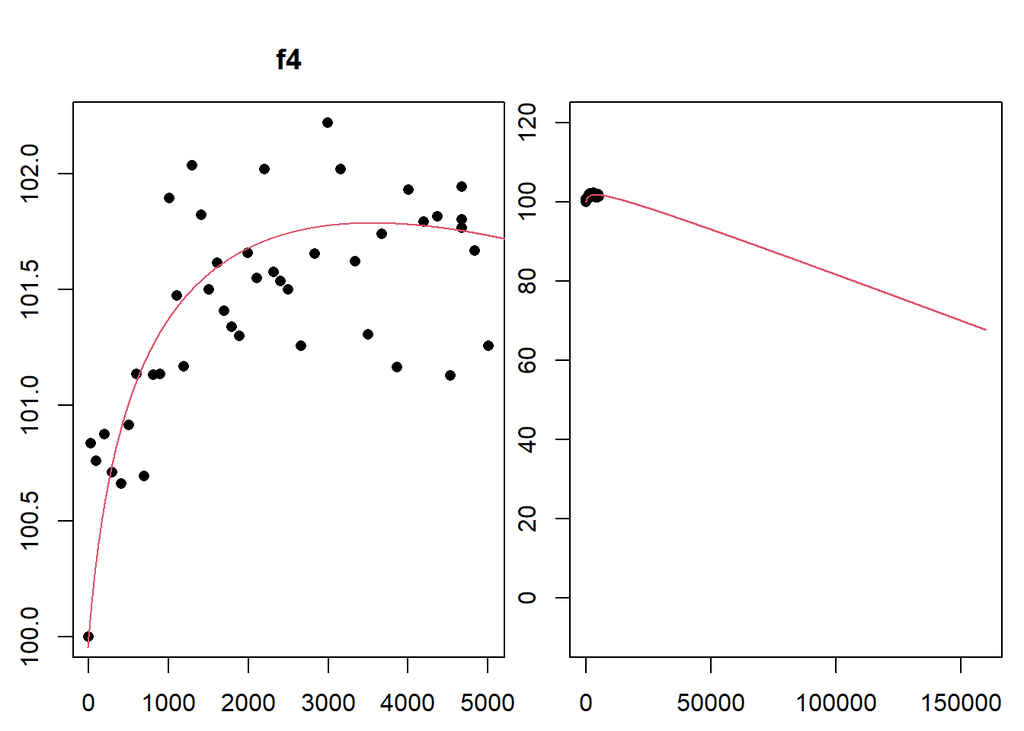

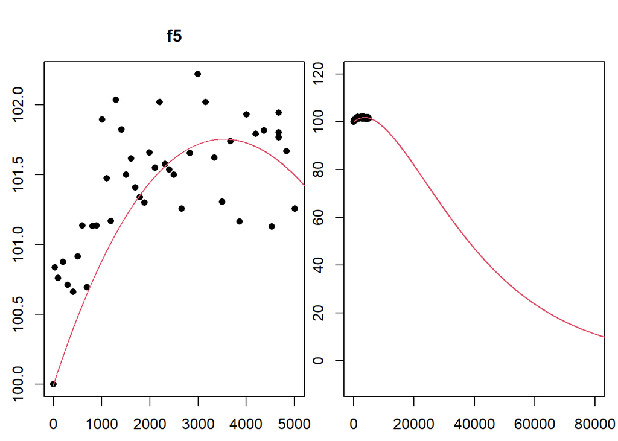

### Description of Model Fitting

The process of fitting these models involves adjusting the parameters within the equations to best align with the experimental data. This fitting process helps us understand how well each model approximates the behavior of LED bulbs over time.

### Provided Fitted Models

```r
result_y2
```

```
## $root
## [1] 16584.3
##
## $f.root
## [1] 7.642547e-08
##
## $iter
## [1] 11
##
## $init.it
## [1] NA
##
## $estim.prec
## [1] 6.103516e-05
```

```r
result_y4
```

```
## $root
## [1] 106895.2
##
## $f.root
## [1] 4.772005e-11
##
## $iter
## [1] 5
##
## $init.it
## [1] NA
##
## $estim.prec
## [1] 6.10352e-05
```

6. **$f_5$**: The equation is represented as:
   $$f_5(x,a0=100,a1=6 \times 10^{-3},a2=4.95 \times
   10^{-5}) = (a0 + a1x)e^{-a2x}$$
   This model suggests that the intensity grows to a maximum of 101.8% and then decreases to 80% at around 20956.8 hours, suggesting a lifespan of nearly 2.4 years.

```r
result_y5
```

```
## $root
## [1] 20956.77
##
## $f.root
## [1] 5.348281e-08
##
## $iter
## [1] 6
##
## $init.it
## [1] NA
##
## $estim.prec
## [1] 6.103517e-05
```

### Interesting Stories from Fitted Models

**1. Infinite Lifespan Models ($f_0$ and $f_1$):**

Models $f_0$ and $f_1$ suggest infinite lifespans, with constant intensity or increasing intensity over time. While these models may not be realistic for LED light bulbs, they introduce an interesting concept of theoretical models that challenge common assumptions. This emphasizes the need for models to be not only consistent with data but also plausible in the context of the phenomenon being studied.

**2. Curvature in $f_2$:**

Model `f_2` introduces a quadratic term, resulting in a curve in the intensity pattern. The curve suggests an initial growth in intensity, reaching a maximum, and then declining. This model provides a nuanced view of the lifespan and behavior of LED bulbs, capturing a more complex trajectory compared to linear models.

**3. Logarithmic Decline in $f_4$:**

Model $f_4$ includes a logarithmic term in the intensity equation, leading to a gradual decline after reaching the maximum intensity. The logarithmic behavior introduces an interesting mathematical element to the model, indicating a slower decay in intensity compared to linear models. This showcases the diversity of mathematical forms that can be used to represent real-world phenomena.

**4. Exponential Decline in $f_5$:**

Model $f_5$` incorporates an exponential term, resulting in a rapid initial growth in intensity followed by a faster decline. This model provides insights into the potential rapid degradation of LED bulbs after reaching their peak intensity. The exponential decline is a reminder of how different mathematical functions can capture distinct aspects of a system’s behavior.

### Consistency with Known Information

**2. Inconsistencies with Other Models**

It’s essential to note the inconsistencies in other models, such as $f_2$ and $f_5$, which suggest lifespans of 1.9 years and 2.4 years, respectively. These models may not align well with known information about LED bulb lifespans and intensity patterns. This reinforces the importance of model selection in drawing accurate conclusions from data.

### Answer to the Question

For each model, the lifespan differs greatly. Let’s summarize the findings:

**1. Model $f_0$:**

- Lifespan: Infinite
- Description: This model suggests a constant intensity of 100% throughout the bulbs’ lifespan, implying an infinite lifespan. While this may not align with the reality of LED light bulbs, it introduces an interesting theoretical concept.

**2. Model $f_1$:**

- Lifespan: Infinite
- Description: Similar to $f_0$, this model implies an infinite lifespan, with the intensity increasing over time. Again, this is a theoretical scenario that challenges common assumptions.

**4. Model $f_3$:**

- Lifespan: Infinite
- Description: This model suggests that the intensity grows to a maximum slightly above 101% and then plateaus around 3,000 hours, with slight continuous growth. This implies an infinite lifespan.

**6. Model $f_5$:**

- Lifespan: Approximately 2.4 years
- Description: The intensity grows to a maximum of 101.8% and then decreases to 80% at around 20,956.8 hours, suggesting a lifespan of nearly 2.4 years.

The analysis of different models provides diverse perspectives on the lifespan of LED light bulbs. While some models suggest infinite lifespans, others propose more realistic duration, ranging from 1.9 years to 12.2 years.

### Importance of Model Dependence

Understanding that the information we obtain from data depends on the model we assume is crucial when working with models and data. Different models can provide vastly different interpretations of the same data. In this case, selecting the correct model is essential to draw accurate conclusions about the lifespan of LED light bulbs. Using an incorrect model can lead to misleading or inaccurate results, as demonstrated by the inconsistency of some models with known LED bulb behavior. Therefore, choosing an appropriate model is a critical step in data analysis and interpretation.

### Key Mathematical Ideas:

The concept of fitting mathematical models to real-world data to make predictions and draw conclusions. The importance of understanding the limitations and assumptions of different models.

### Soft Skills:

- Dedication: Completing the project by following instructions and organizing the analysis cohesively.
- Organization: Structuring the document in a logical and clear manner.
- Perseverance: Continuously evaluating and refining the models to draw meaningful conclusions.